# Session Level Measures Replication in ASSISTments (for JEDM)

#### Relevant Papers

1. Brezack, Natalie, Shuangting Yang, Jenna Grady, Abby Lavine, Mingyu Feng, and Linlin Li. “Teacher Perspectives on Student Self-Regulated Learning in a Math Formative Assessment Platform.” Proceedings of the Twelfth ACM Conference on Learning @ Scale. New York, NY, USA: ACM, July 17, 2025. https://doi.org/10.1145/3698205.3733949.
2. Feng, Mingyu, Linlin Li, Chunwei Huang, Natalie Brezack, and Kim Luttgen. “Empowering Teachers with Technology: A National Study on a Formative Assessment Platform.” In Communications in Computer and Information Science, 119–26. Cham: Springer Nature Switzerland, 2025. https://doi.org/10.1007/978-3-031-99267-4_15.

**NOTE: The main replication model included in the paper is presented in section labelled** *“JEDM: Paper Replication Model.”*

```r
library(dplyr)
library(lubridate)
library(tidyr)
library(ggplot2)
library(stringr)
library(lme4)
library(sjPlot)
library(cowplot)
library(purrr)
library(data.table)
library(estimatr)
```

```r
df_problem_logs_main <- read.csv("../data/problemlogs/BothCohorts_problemLogs.csv")
df_problem_logs_system <- read.csv("../data/problemlogs/problemlogids_full.csv")
df_problem_logs_main <- df_problem_logs_main %>%
  subset(!(problemLogID %in% (df_problem_logs_system %>% subset(attempt_count == 0 & hint_count == 0 & saw_answer == "false"))$id))

df_core_codebook <- read.csv("../data/corefiles/ScalingTeachersProfDevForASSISTments_codebook.csv")
df_core_assistments_summary <- read.csv("../data/corefiles/ScalingTeachersProfDevForASSISTments_data.csv")

df_low_classwork_filter <- read.csv("../data/problemlogs/df_low_classwork_filter.csv")

df_low_classwork_filter_ <- df_low_classwork_filter %>%
  subset(classwork_sessions > 10 & avg_size > 5 & avg_length > 12)
```

```r
df_actionlogs <- read.csv("../data/actionlogs/ASSISTments_experiment_actionlogs.csv")
```

```r
df_problem_logs <- df_problem_logs_main %>%
  group_by (class_id) %>%
  arrange (class_id, start_time) %>%
  mutate(event_time_localtime = with_tz(ymd_hms(start_time, tz = "UTC"), tzone = "America/New_York"),
         event_time_year = year(event_time_localtime),
         event_time_month = month(event_time_localtime),
         event_time_day = day(event_time_localtime),) %>%
  ungroup()
```

```r
df_student_id_pl <- inner_join(
  df_problem_logs_main %>% select(studyStudentID, problemLogID, class_id),
  df_problem_logs_system %>% select(id, assignment_log_id), by = c("problemLogID" = "id"))

df_student_id_pl <- inner_join(df_student_id_pl,
                               df_core_assistments_summary %>%
                                 distinct(state, stu_id, sch_id, tea_id, classid, treat, cohort, grade, locale, .keep_all = TRUE) %>%
                                 select(state, stu_id, sch_id, tea_id, classid, treat, cohort, grade, locale, score_1, score_2),
                               by = c("studyStudentID" = "stu_id"))

df_student_id_pl <- left_join(df_low_classwork_filter_ %>% select(state, classid), df_student_id_pl, by=c("state", "classid"))

df_student_id_pl <- df_student_id_pl %>%
  distinct(state, classid, studyStudentID, class_id, assignment_log_id, sch_id, tea_id, treat, cohort, grade, locale, .keep_all = TRUE)
```

### Timezones

let us figureout the timezone of all the states

```r
df_state_timezone = data.frame(
  state = c("DC", "GA", "MA", "NJ", "NY", "RI", "TN", "IN", "KY", "MI", "AR", "IA", "IL", "LA", "MO", "UT", "AZ", "CA", "HI", "QK"),
  timezone_conversion_label = c("America/New_York", "America/New_York", "America/New_York", "America/New_York", "America/New_York", "America/New_York", "America/New_York", "America/New_York", "America/New_York", "America/New_York",
                                "America/Chicago", "America/Chicago", "America/Chicago", "America/Chicago", "America/Chicago", "America/Denver", "America/Phoenix", "America/Los_Angeles", "Pacific/Honolulu", "America/Toronto"))
```

```r
df_actionlogs <- df_actionlogs %>%
  select(-c(id, action_type_id, old_target_xref, old_path, tutor_uid_id, tutor_uid_sequence, old_extra_property_json, target_xref))

df_actionlogs_ <- left_join(df_student_id_pl, df_actionlogs, by=c("assignment_log_id"))
df_actionlogs_ <- left_join(df_actionlogs_, df_state_timezone, by=c("state"))
```

```r
nrow(df_actionlogs)
```

```
## [1] 5737287
```

```r
nrow(df_actionlogs_)
```

```
## [1] 2790753
```

```r
compute_session_info <- function(df_temp, timezone_lable) {
  df_temp <- df_temp %>%
    arrange(classid, timestamp) %>%
    group_by(classid) %>%
    mutate(
      event_timestamp = with_tz(ymd_hms(timestamp, tz='UTC'), tzone = timezone_lable),
      event_timestamp_year = year(event_timestamp),
      event_timestamp_month = month(event_timestamp),
      event_timestamp_day = day(event_timestamp),
      event_timestamp_hour = hour(event_timestamp),
      next_event_timestamp = lead(event_timestamp),
      time_diff = round(as.numeric(difftime(next_event_timestamp, event_timestamp, units="mins")),3),
      time_diff = coalesce(time_diff, 0.001)) %>%
    mutate(session_break_7_5 = if_else(time_diff > (7.5), 1, 0),
           class_session_id_7_5 = paste0("class_session_", cumsum(lag(session_break_7_5, default = 0)))) %>%
    ungroup()


  df_class_session_info <- df_temp %>%
    group_by(state, sch_id, tea_id, classid,  class_session_id_7_5) %>%
    summarise(class_session_length = round(as.numeric(difftime(max(event_timestamp), min(event_timestamp), units="mins")),3),
              class_session_size = n_distinct(studyStudentID),
              class_session_start_hour = min(event_timestamp_hour),
              class_session_end_hour = max(event_timestamp_hour),
              class_session_start_time = min(event_timestamp),
              class_session_end_time = max(event_timestamp),
              counting = n(),
              class_session_type = case_when(class_session_start_hour >= 7 & class_session_end_hour <= 15 & class_session_size < 5 ~ "at school independent work",
                                             class_session_start_hour >= 7 & class_session_end_hour <= 15 & class_session_size >= 5 ~ "classwork",
                                             TRUE~"homework 1"))

  df_student_session_info <- df_temp %>%
    arrange(state, sch_id, tea_id, classid, class_session_id_7_5, studyStudentID, timestamp) %>%
    group_by(state, sch_id, tea_id, classid, class_session_id_7_5, studyStudentID, grade, locale, score_1, score_2) %>%
    mutate(student_next_timestamp = lead(event_timestamp),
           student_time_diff = round(as.numeric(difftime(student_next_timestamp, event_timestamp, units="mins")),3),
           student_time_diff = coalesce(time_diff, 0.001)) %>%
    summarise(tx_count = n(),
              student_session_length = round(as.numeric(difftime(max(event_timestamp), min(event_timestamp), units="mins")),3),
              idle_time_gt_120 = sum(ifelse(student_time_diff > 1.05 & student_time_diff < 7.5, student_time_diff, 0)),
              student_session_start_time = min(event_timestamp),
              student_session_end_time = max(event_timestamp),
              student_session_start_year = min(event_timestamp_year),
              student_session_start_month = min(event_timestamp_month),
              student_session_start_day = min(event_timestamp_day))


  intersect(colnames(df_student_session_info), colnames(df_class_session_info))

  df_session_merged = left_join(df_class_session_info, df_student_session_info, by=c("state", "classid", "tea_id", "sch_id", "class_session_id_7_5"))

  df_session_merged <- df_session_merged %>%
    mutate(student_delayed_start = round(as.numeric(difftime(student_session_start_time, class_session_start_time, units="mins")), 3),
           student_early_stop = round(as.numeric(difftime(class_session_end_time, student_session_end_time, units="mins")), 3)) %>%
    group_by(classid, class_session_id_7_5) %>%
    mutate(
      relative_student_delayed_start = as.numeric(scale(student_delayed_start)),
      relative_student_session_length = as.numeric(scale(student_session_length)),
      relative_student_early_stop = as.numeric(scale(student_early_stop)),
      relative_idle_time_gt_120 = as.numeric(scale(idle_time_gt_120)))
  return(df_session_merged)
}

df_problem_logs_NY <- compute_session_info(subset(df_actionlogs_, timezone_conversion_label == "America/New_York"), "America/New_York")
```

```
## can override using the `.groups` argument.
## 'class_session_id_7_5', 'studyStudentID', 'grade', 'locale', 'score_1'. You can
```

```r
df_problem_logs_Chi <- compute_session_info(subset(df_actionlogs_, timezone_conversion_label == "America/Chicago"), "America/Chicago")
```

```
## can override using the `.groups` argument.
## 'class_session_id_7_5', 'studyStudentID', 'grade', 'locale', 'score_1'. You can
```

```r
df_problem_logs_Den <- compute_session_info(subset(df_actionlogs_, timezone_conversion_label == "America/Denver"), "America/Denver")
```

```
## can override using the `.groups` argument.
## 'class_session_id_7_5', 'studyStudentID', 'grade', 'locale', 'score_1'. You can
```

```r
df_problem_logs_AZ <- compute_session_info(subset(df_actionlogs_, timezone_conversion_label == "America/Phoenix"), "America/Phoenix")
```

```
## can override using the `.groups` argument.
## 'class_session_id_7_5', 'studyStudentID', 'grade', 'locale', 'score_1'. You can
```

```r
df_problem_logs_LA <- compute_session_info(subset(df_actionlogs_, timezone_conversion_label == "America/Los_Angeles"), "America/Los_Angeles")
```

```
## can override using the `.groups` argument.
## 'class_session_id_7_5', 'studyStudentID', 'grade', 'locale', 'score_1'. You can
```

```r
df_problem_logs_HI <- compute_session_info(subset(df_actionlogs_, timezone_conversion_label == "Pacific/Honolulu"), "Pacific/Honolulu")
```

```
## can override using the `.groups` argument.
## 'class_session_id_7_5', 'studyStudentID', 'grade', 'locale', 'score_1'. You can
```

```r
df_problem_logs_QK <- compute_session_info(subset(df_actionlogs_, timezone_conversion_label == "America/Toronto"), "America/Toronto")
```

```
## can override using the `.groups` argument.
## 'class_session_id_7_5', 'studyStudentID', 'grade', 'locale', 'score_1'. You can
```

```r
df_problem_logs_session_info <- rbind(df_problem_logs_NY, df_problem_logs_Chi, df_problem_logs_Den, df_problem_logs_AZ, df_problem_logs_LA, df_problem_logs_HI, df_problem_logs_QK)

df_problem_logs_session_info %>%
  group_by(classid, class_session_id_7_5, class_session_type, class_session_length, class_session_size) %>%
  summarise(counting = n()) %>%
  ungroup() %>%
  group_by(class_session_type) %>%
  summarise(mean(class_session_length), median(class_session_length), sd(class_session_length), mean(class_session_size), median(class_session_size), sd(class_session_size))
```

```
## 'class_session_type', 'class_session_length'. You can override using the
```

| class_session_type | mean(class_session_length) | median(class_session_length) | sd(class_session_length) | mean(class_session_size) | median(class_session_size) | sd(class_session_size) |
| --- | --- | --- | --- | --- | --- | --- |
| at school independent work | 7.232244 | 4.1350 | 9.068044 | 1.368063 | 1 | 0.7525860 |
| classwork | 25.882440 | 22.0095 | 16.900791 | 12.916074 | 13 | 5.7928708 |
| homework 1 | 10.800074 | 6.2670 | 14.616130 | 1.191156 | 1 | 0.8349804 |

## Measuers from the paper

1. delayed start (raw and realtive)
2. session length (raw and realtive)
3. early stop (raw and relative)
4. idle time (raw and realtive)
5. total time on task (mins)
6. usage time ratio (raw and realtive)
7. attendance
8. gaming tendency

```r
df_student_monthly_summary_1 <- df_problem_logs_session_info %>%
  filter(!(student_session_start_month %in% c(5, 6, 7))) %>%
  group_by(classid) %>%
  mutate(class_size = n_distinct(studyStudentID)) %>%
  group_by(classid, studyStudentID, student_session_start_year, student_session_start_month, class_size, state, tea_id, sch_id, grade, locale, score_1, score_2) %>%
  summarise(total_time_on_task_raw = sum(na.omit(student_session_length)),
            total_time_on_task_raw_80s = total_time_on_task_raw - sum(na.omit(idle_time_gt_120)),
            class_session_types = paste(unique(class_session_type), collapse = ", "))
```

```
## 'student_session_start_year', 'student_session_start_month', 'class_size',
## 'state', 'tea_id', 'sch_id', 'grade', 'locale', 'score_1'. You can override
```

```r
df_student_monthly_summary_2 <- df_problem_logs_session_info %>%
  filter(!(student_session_start_month %in% c(5, 6, 7))) %>%
  filter(class_session_type == "classwork") %>%
  group_by(classid, studyStudentID, student_session_start_year, student_session_start_month) %>%
  summarise(class_session_size = mean(class_session_size),
            attendance = sum(na.omit(ifelse(class_session_type == "classwork", 1, NA))),
            delayed_start_raw = mean(na.omit(ifelse(class_session_type == "classwork", student_delayed_start, NA))),
            delayed_start_relative = mean(na.omit(ifelse(class_session_type == "classwork", relative_student_delayed_start, NA))),
            session_length_raw = mean(na.omit(ifelse(class_session_type == "classwork", student_session_length, NA))),
            session_length_relative = mean(na.omit(ifelse(class_session_type == "classwork", relative_student_session_length, NA))),
            early_stop_raw = mean(na.omit(ifelse(class_session_type == "classwork", student_early_stop, NA))),
            early_stop_relative = mean(na.omit(ifelse(class_session_type == "classwork", relative_student_early_stop, NA))),
            idle_time_raw = mean(na.omit(ifelse(class_session_type == "classwork", idle_time_gt_120, NA))),
            idle_time_relative = mean(na.omit(ifelse(class_session_type == "classwork", relative_idle_time_gt_120, NA))),
            student_total_classwork_sessions = n_distinct(class_session_id_7_5))
```

```
## 'student_session_start_year'. You can override using the `.groups` argument.
```

```r
df_student_monthly_summary <- left_join(df_student_monthly_summary_1,
                                        df_student_monthly_summary_2,
                                        by=c("classid", "studyStudentID", "student_session_start_year", "student_session_start_month"))

df_class_monthly_summary <- df_problem_logs_session_info %>%
  filter(class_session_type == "classwork") %>%
  group_by(classid, student_session_start_year, student_session_start_month, class_session_id_7_5, class_session_length) %>%
  summarise(counting = n()) %>%
  ungroup() %>%
  group_by(classid, student_session_start_year, student_session_start_month) %>%
  summarise(total_classwork_sessions = n_distinct(class_session_id_7_5),
            total_classwork_session_length = sum(na.omit(class_session_length)))
```

```
## 'student_session_start_month', 'class_session_id_7_5'. You can override using
## You can override using the `.groups` argument.
```

```r
df_student_monthly_summary <- left_join(df_student_monthly_summary, df_class_monthly_summary,
                                        by=c("classid", "student_session_start_year", "student_session_start_month"))

df_student_monthly_summary <- df_student_monthly_summary %>%
  mutate(attendance = student_total_classwork_sessions/total_classwork_sessions,
         usage_time_ratio = total_time_on_task_raw/total_classwork_session_length) %>%
  group_by(classid, student_session_start_month) %>%
  mutate(relative_usage_time_ratio = as.numeric(scale(usage_time_ratio)))
```

1. filter out the less frequent observations to clean up the data.

```r
df_check = df_student_monthly_summary %>%
  filter(grepl("classwork", class_session_types)) %>%
  group_by(classid) %>%
  summarise(months = n_distinct(student_session_start_month)) %>%
  filter(months > 4)

df_student_monthly_summary_final <- df_student_monthly_summary %>%
  filter(classid %in% unique(df_check$classid)) %>%
  ungroup()

df_gaming_tendnecy <- read.csv("../data/actionlogs/df_full_merged_gaming_logs_long.csv")
df_student_monthly_summary_final <- left_join(df_student_monthly_summary_final, df_gaming_tendnecy, by=c("studyStudentID", "student_session_start_month" = "month"))

colnames(df_student_monthly_summary_final)
```

```
##  [1] "classid"                          "studyStudentID"
##  [3] "student_session_start_year"       "student_session_start_month"
##  [5] "class_size"                       "state"
##  [7] "tea_id"                           "sch_id"
##  [9] "grade"                            "locale"
## [11] "score_1"                          "score_2"
## [13] "total_time_on_task_raw"           "total_time_on_task_raw_80s"
## [15] "class_session_types"              "class_session_size"
## [17] "attendance"                       "delayed_start_raw"
## [19] "delayed_start_relative"           "session_length_raw"
## [21] "session_length_relative"          "early_stop_raw"
## [23] "early_stop_relative"              "idle_time_raw"
## [25] "idle_time_relative"               "student_total_classwork_sessions"
## [27] "total_classwork_sessions"         "total_classwork_session_length"
## [29] "usage_time_ratio"                 "relative_usage_time_ratio"
## [31] "na_count"                         "latent_gaming_estimate"
```

# compute annual numbers

```r
df_student_summary1 <- df_student_monthly_summary_final %>%
  # group_by(class_id, classid, studyStudentID) %>%
  group_by(studyStudentID) %>%
  summarise(classes = n_distinct(classid),
            delayed_start_raw = mean(na.omit(delayed_start_raw)),
            delayed_start_relative = mean(na.omit(delayed_start_relative)),
            session_length_raw = mean(na.omit(session_length_raw)),
            session_length_relative = mean(na.omit(session_length_relative)),
            early_stop_raw = mean(na.omit(early_stop_raw)),
            early_stop_relative = mean(na.omit(early_stop_relative)),
            idle_time_raw = mean(na.omit(idle_time_raw)),
            idle_time_relative = mean(na.omit(idle_time_relative)),
            student_total_classwork_sessions = sum(na.omit(student_total_classwork_sessions)),
            months = n_distinct(na.omit(ifelse(grepl('classwork', tolower(class_session_types)), student_session_start_month, NA))))

df_student_summary2 <- df_problem_logs_session_info %>%
  filter(classid %in% unique(df_check$classid)) %>%
  filter(!(student_session_start_month %in% c(5, 6, 7))) %>%
  group_by(classid) %>%
  mutate(class_size = n_distinct(studyStudentID)) %>%
  group_by(classid, studyStudentID, class_size, state, tea_id, sch_id, grade, locale, score_1, score_2) %>%
  summarise(total_time_on_task_raw = sum(na.omit(student_session_length)),
            total_time_on_task_raw_80s = total_time_on_task_raw - sum(na.omit(idle_time_gt_120)),
            class_session_types = paste(unique(class_session_type), collapse = ", "))
```

```
## 'state', 'tea_id', 'sch_id', 'grade', 'locale', 'score_1'. You can override
```

```r
df_class_summary <- df_problem_logs_session_info %>%
  filter(class_session_type == "classwork") %>%
  group_by(classid, class_session_id_7_5, class_session_length) %>%
  summarise(counting = n()) %>%
  ungroup() %>%
  group_by(classid) %>%
  summarise(total_classwork_sessions = n_distinct(class_session_id_7_5),
            total_classwork_session_length = sum(na.omit(class_session_length)))
df_student_summary <- left_join(df_student_summary2, df_student_summary1, by=c("studyStudentID"))
```

```r
df_student_summary_final <- left_join(df_student_summary, df_class_summary, by=c("classid"))

df_student_summary_final <- left_join(df_student_summary_final,
                                      df_gaming_tendnecy %>%
                                        filter(month == 0) %>%
                                        select(studyStudentID, latent_gaming_estimate),
                                      by=c("studyStudentID"))

df_student_summary_final <- df_student_summary_final %>%
  mutate(attendance = student_total_classwork_sessions/total_classwork_sessions,
         usage_time_ratio = total_time_on_task_raw/total_classwork_session_length) %>%
  group_by(classid) %>%
  mutate(relative_usage_time_ratio = as.numeric(scale(usage_time_ratio))) %>%
  ungroup()
```

```r
n_distinct(df_student_monthly_summary_final$studyStudentID)
```

```
## [1] 1353
```

```r
n_distinct(df_student_summary$studyStudentID)
```

```
## [1] 1353
```

```r
df_student_summary_final_ <- df_student_summary_final %>%
  filter(!is.na(delayed_start_relative))

df_student_summary_final_ <- df_student_summary_final_ %>%
  mutate(delayed_start_raw = log(delayed_start_raw + 1),
         session_length_raw = (session_length_raw)^(1/2),
         early_stop_raw = (early_stop_raw)^(1/2),
         idle_time_raw = log((idle_time_raw + 1)*100),
         total_time_on_task_raw = log(total_time_on_task_raw),
         usage_time_ratio = log(usage_time_ratio + 1),
         attendance = attendance^2
         )

nrow(df_student_summary_final_)
```

```
## [1] 1347
```

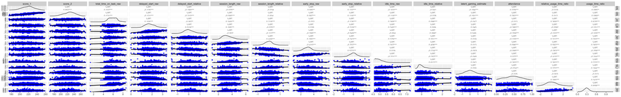

```r
library(GGally)

ggpairs(df_student_summary_final_,
        columns = c(#'locale',
                    'score_1', 'score_2', 'total_time_on_task_raw', 'delayed_start_raw', 'delayed_start_relative',
                    'session_length_raw', 'session_length_relative', 'early_stop_raw', 'early_stop_relative', 'idle_time_raw', 'idle_time_relative',
                    'latent_gaming_estimate', "attendance", "relative_usage_time_ratio", "usage_time_ratio"),
        upper = list(continuous = wrap("cor", size = 3)),
        lower = list(continuous = wrap("smooth", method = "lm", se = FALSE, color = 'blue')),
        diag  = list(continuous = "density", alpha = 0.5),
        progress = FALSE)
```

## Computing G and Phi coefficients for reliability analysis

```r
model1 <- lmer(delayed_start_raw ~ (1|studyStudentID) + (1|student_session_start_month), data = df_student_monthly_summary_final)
model2 <- lmer(delayed_start_relative ~ (1|studyStudentID) + (1|student_session_start_month), data = df_student_monthly_summary_final)
```

```
## boundary (singular) fit: see help('isSingular')
```

```r
tab_model(model1, model2)
```

|  | delayed_start_raw |  |  | delayed_start_relative |  |  |
| --- | --- | --- | --- | --- | --- | --- |
| Predictors | Estimates | CI | p | Estimates | CI | p |
| (Intercept) | 5.60 | 5.23 – 5.97 | **<0.001** | 0.03 | 0.01 – 0.06 | **0.005** |
| Random Effects |  |  |  |  |  |  |
| σ<sup>2</sup> | 26.65 |  |  | 0.36 |  |  |
| τ<sub>00</sub> | 7.01 <sub>studyStudentID</sub> |  |  | 0.13 <sub>studyStudentID</sub> |  |  |
|  | 0.25 <sub>student_session_start_month</sub> |  |  | 0.00 <sub>student_session_start_month</sub> |  |  |
| ICC | 0.21 |  |  |  |  |  |
| N | 1347 <sub>studyStudentID</sub> |  |  | 1347 <sub>studyStudentID</sub> |  |  |
|  | 9 <sub>student_session_start_month</sub> |  |  | 9 <sub>student_session_start_month</sub> |  |  |
| Observations | 9531 |  |  | 9531 |  |  |
| Marginal R<sup>2</sup> / Conditional R<sup>2</sup> | 0.000 / 0.214 |  |  | 0.000 / NA |  |  |

```r
df_ref1 <- as.data.frame(VarCorr(model1))
rownames(df_ref1) <- df_ref1$grp
print(df_ref1["studyStudentID", "vcov"]/(df_ref1["studyStudentID", "vcov"] + ((df_ref1["Residual", "vcov"])/10)))
```

```
## [1] 0.7244638
```

```r
print(df_ref1["studyStudentID", "vcov"]/(df_ref1["studyStudentID", "vcov"] + ((df_ref1["Residual", "vcov"] + df_ref1["student_session_start_month", "vcov"])/10)))
```

```
## [1] 0.7226067
```

```r
df_ref2 <- as.data.frame(VarCorr(model2))
rownames(df_ref2) <- df_ref2$grp
print(df_ref2["studyStudentID", "vcov"]/(df_ref2["studyStudentID", "vcov"] + ((df_ref2["Residual", "vcov"])/10)))
```

```
## [1] 0.7786387
```

```r
print(df_ref2["studyStudentID", "vcov"]/(df_ref2["studyStudentID", "vcov"] + ((df_ref2["Residual", "vcov"] + df_ref2["student_session_start_month", "vcov"])/10)))
```

```
## [1] 0.7786387
```

```r
model3 <- lmer(session_length_raw ~ (1|studyStudentID) + (1|student_session_start_month), data = df_student_monthly_summary_final)
model4 <- lmer(session_length_relative ~ (1|studyStudentID) + (1|student_session_start_month), data = df_student_monthly_summary_final)
```

```
## boundary (singular) fit: see help('isSingular')
```

```r
tab_model(model3, model4)
```

|  | session_length_raw |  |  | session_length_relative |  |  |
| --- | --- | --- | --- | --- | --- | --- |
| Predictors | Estimates | CI | p | Estimates | CI | p |
| (Intercept) | 11.14 | 10.60 – 11.68 | **<0.001** | -0.01 | -0.03 – 0.01 | 0.402 |
| Random Effects |  |  |  |  |  |  |
| σ<sup>2</sup> | 50.36 |  |  | 0.36 |  |  |
| τ<sub>00</sub> | 11.20 <sub>studyStudentID</sub> |  |  | 0.06 <sub>studyStudentID</sub> |  |  |
|  | 0.56 <sub>student_session_start_month</sub> |  |  | 0.00 <sub>student_session_start_month</sub> |  |  |
| ICC | 0.19 |  |  |  |  |  |
| N | 1347 <sub>studyStudentID</sub> |  |  | 1347 <sub>studyStudentID</sub> |  |  |
|  | 9 <sub>student_session_start_month</sub> |  |  | 9 <sub>student_session_start_month</sub> |  |  |
| Observations | 9531 |  |  | 9531 |  |  |
| Marginal R<sup>2</sup> / Conditional R<sup>2</sup> | 0.000 / 0.189 |  |  | 0.000 / NA |  |  |

```r
df_ref1 <- as.data.frame(VarCorr(model3))
rownames(df_ref1) <- df_ref1$grp
print(df_ref1["studyStudentID", "vcov"]/(df_ref1["studyStudentID", "vcov"] + ((df_ref1["Residual", "vcov"])/10)))
```

```
## [1] 0.6897846
```

```r
print(df_ref1["studyStudentID", "vcov"]/(df_ref1["studyStudentID", "vcov"] + ((df_ref1["Residual", "vcov"] + df_ref1["student_session_start_month", "vcov"])/10)))
```

```
## [1] 0.687422
```

```r
df_ref2 <- as.data.frame(VarCorr(model4))
rownames(df_ref2) <- df_ref2$grp
print(df_ref2["studyStudentID", "vcov"]/(df_ref2["studyStudentID", "vcov"] + ((df_ref2["Residual", "vcov"])/10)))
```

```
## [1] 0.6229923
```

```r
print(df_ref2["studyStudentID", "vcov"]/(df_ref2["studyStudentID", "vcov"] + ((df_ref2["Residual", "vcov"] + df_ref2["student_session_start_month", "vcov"])/10)))
```

```
## [1] 0.6229923
```

```r
model5 <- lmer(early_stop_raw ~ (1|studyStudentID) + (1|student_session_start_month), data = df_student_monthly_summary_final)
model6 <- lmer(early_stop_relative ~ (1|studyStudentID) + (1|student_session_start_month), data = df_student_monthly_summary_final)
```

```
## boundary (singular) fit: see help('isSingular')
```

```r
tab_model(model5, model6)
```

|  | early_stop_raw |  |  | early_stop_relative |  |  |
| --- | --- | --- | --- | --- | --- | --- |
| Predictors | Estimates | CI | p | Estimates | CI | p |
| (Intercept) | 9.86 | 9.09 – 10.63 | **<0.001** | -0.01 | -0.03 – 0.01 | 0.385 |
| Random Effects |  |  |  |  |  |  |
| σ<sup>2</sup> | 45.53 |  |  | 0.35 |  |  |
| τ<sub>00</sub> | 11.16 <sub>studyStudentID</sub> |  |  | 0.09 <sub>studyStudentID</sub> |  |  |
|  | 1.27 <sub>student_session_start_month</sub> |  |  | 0.00 <sub>student_session_start_month</sub> |  |  |
| ICC | 0.21 |  |  |  |  |  |
| N | 1347 <sub>studyStudentID</sub> |  |  | 1347 <sub>studyStudentID</sub> |  |  |
|  | 9 <sub>student_session_start_month</sub> |  |  | 9 <sub>student_session_start_month</sub> |  |  |
| Observations | 9531 |  |  | 9531 |  |  |
| Marginal R<sup>2</sup> / Conditional R<sup>2</sup> | 0.000 / 0.214 |  |  | 0.000 / NA |  |  |

```r
df_ref1 <- as.data.frame(VarCorr(model5))
rownames(df_ref1) <- df_ref1$grp
print(df_ref1["studyStudentID", "vcov"]/(df_ref1["studyStudentID", "vcov"] + ((df_ref1["Residual", "vcov"])/10)))
```

```
## [1] 0.7101728
```

```r
print(df_ref1["studyStudentID", "vcov"]/(df_ref1["studyStudentID", "vcov"] + ((df_ref1["Residual", "vcov"] + df_ref1["student_session_start_month", "vcov"])/10)))
```

```
## [1] 0.7044846
```

```r
df_ref2 <- as.data.frame(VarCorr(model6))
rownames(df_ref2) <- df_ref2$grp
print(df_ref2["studyStudentID", "vcov"]/(df_ref2["studyStudentID", "vcov"] + ((df_ref2["Residual", "vcov"])/10)))
```

```
## [1] 0.7167331
```

```r
print(df_ref2["studyStudentID", "vcov"]/(df_ref2["studyStudentID", "vcov"] + ((df_ref2["Residual", "vcov"] + df_ref2["student_session_start_month", "vcov"])/10)))
```

```
## [1] 0.7167331
```

```r
# model7 <- lmer(idle_time_raw ~ (1|studyStudentID) + (1|student_session_start_month) + (1|studyStudentID:student_session_start_month), data = df_student_monthly_summary_final)
model7 <- lmer(idle_time_raw ~ (1|studyStudentID) + (1|student_session_start_month), data = df_student_monthly_summary_final)
model8 <- lmer(idle_time_relative ~ (1|studyStudentID) + (1|student_session_start_month), data = df_student_monthly_summary_final)
```

```
## boundary (singular) fit: see help('isSingular')
```

```r
tab_model(model7, model8)
```

|  | idle_time_raw |  |  | idle_time_relative |  |  |
| --- | --- | --- | --- | --- | --- | --- |
| Predictors | Estimates | CI | p | Estimates | CI | p |
| (Intercept) | 0.50 | 0.45 – 0.55 | **<0.001** | 0.01 | -0.01 – 0.02 | 0.534 |
| Random Effects |  |  |  |  |  |  |
| σ<sup>2</sup> | 1.38 |  |  | 0.43 |  |  |
| τ<sub>00</sub> | 0.16 <sub>studyStudentID</sub> |  |  | 0.02 <sub>studyStudentID</sub> |  |  |
|  | 0.00 <sub>student_session_start_month</sub> |  |  | 0.00 <sub>student_session_start_month</sub> |  |  |
| ICC | 0.10 |  |  |  |  |  |
| N | 1347 <sub>studyStudentID</sub> |  |  | 1347 <sub>studyStudentID</sub> |  |  |
|  | 9 <sub>student_session_start_month</sub> |  |  | 9 <sub>student_session_start_month</sub> |  |  |
| Observations | 9531 |  |  | 8743 |  |  |
| Marginal R<sup>2</sup> / Conditional R<sup>2</sup> | 0.000 / 0.105 |  |  | 0.000 / NA |  |  |

```r
df_ref1 <- as.data.frame(VarCorr(model7))
rownames(df_ref1) <- df_ref1$grp
print(df_ref1["studyStudentID", "vcov"]/(df_ref1["studyStudentID", "vcov"] + ((df_ref1["Residual", "vcov"])/10)))
```

```
## [1] 0.5342112
```

```r
print(df_ref1["studyStudentID", "vcov"]/(df_ref1["studyStudentID", "vcov"] + ((df_ref1["Residual", "vcov"] + df_ref1["student_session_start_month", "vcov"])/10)))
```

```
## [1] 0.53358
```

```r
df_ref2 <- as.data.frame(VarCorr(model8))
rownames(df_ref2) <- df_ref2$grp
print(df_ref2["studyStudentID", "vcov"]/(df_ref2["studyStudentID", "vcov"] + ((df_ref2["Residual", "vcov"])/10)))
```

```
## [1] 0.3611826
```

```r
print(df_ref2["studyStudentID", "vcov"]/(df_ref2["studyStudentID", "vcov"] + ((df_ref2["Residual", "vcov"] + df_ref2["student_session_start_month", "vcov"])/10)))
```

```
## [1] 0.3611826
```

```r
model9 <- lmer(total_time_on_task_raw ~ (1|studyStudentID) + (1|student_session_start_month), data = df_student_monthly_summary_final)
tab_model(model9)
```

|  | total_time_on_task_raw |  |  |
| --- | --- | --- | --- |
| Predictors | Estimates | CI | p |
| (Intercept) | 61.35 | 45.99 – 76.72 | **<0.001** |
| Random Effects |  |  |  |
| σ<sup>2</sup> | 2889.90 |  |  |
| τ<sub>00</sub> <sub>studyStudentID</sub> | 2603.48 |  |  |
| τ<sub>00</sub> <sub>student_session_start_month</sub> | 532.74 |  |  |
| ICC | 0.52 |  |  |
| N <sub>studyStudentID</sub> | 1353 |  |  |
| N <sub>student_session_start_month</sub> | 9 |  |  |
| Observations | 9998 |  |  |
| Marginal R<sup>2</sup> / Conditional R<sup>2</sup> | 0.000 / 0.520 |  |  |

```r
df_ref1 <- as.data.frame(VarCorr(model9))
rownames(df_ref1) <- df_ref1$grp
print(df_ref1["studyStudentID", "vcov"]/(df_ref1["studyStudentID", "vcov"] + ((df_ref1["Residual", "vcov"])/10)))
```

```
## [1] 0.900089
```

```r
print(df_ref1["studyStudentID", "vcov"]/(df_ref1["studyStudentID", "vcov"] + ((df_ref1["Residual", "vcov"] + df_ref1["student_session_start_month", "vcov"])/10)))
```

```
## [1] 0.8838109
```

```r
model10 <- lmer(usage_time_ratio ~ (1|studyStudentID) + (1|student_session_start_month), data = df_student_monthly_summary_final)
model11 <- lmer(relative_usage_time_ratio ~ (1|studyStudentID) + (1|student_session_start_month), data = df_student_monthly_summary_final)
```

```
## boundary (singular) fit: see help('isSingular')
```

```r
tab_model(model10, model11)
```

|  | usage_time_ratio |  |  | relative_usage_time_ratio |  |  |
| --- | --- | --- | --- | --- | --- | --- |
| Predictors | Estimates | CI | p | Estimates | CI | p |
| (Intercept) | 0.44 | 0.39 – 0.48 | **<0.001** | -0.01 | -0.04 – 0.03 | 0.759 |
| Random Effects |  |  |  |  |  |  |
| σ<sup>2</sup> | 0.12 |  |  | 0.70 |  |  |
| τ<sub>00</sub> | 0.04 <sub>studyStudentID</sub> |  |  | 0.34 <sub>studyStudentID</sub> |  |  |
|  | 0.00 <sub>student_session_start_month</sub> |  |  | 0.00 <sub>student_session_start_month</sub> |  |  |
| ICC | 0.24 |  |  |  |  |  |
| N | 1353 <sub>studyStudentID</sub> |  |  | 1353 <sub>studyStudentID</sub> |  |  |
|  | 9 <sub>student_session_start_month</sub> |  |  | 9 <sub>student_session_start_month</sub> |  |  |
| Observations | 9909 |  |  | 9909 |  |  |
| Marginal R<sup>2</sup> / Conditional R<sup>2</sup> | 0.000 / 0.238 |  |  | 0.000 / NA |  |  |

```r
df_ref1 <- as.data.frame(VarCorr(model10))
rownames(df_ref1) <- df_ref1$grp
print(df_ref1["studyStudentID", "vcov"]/(df_ref1["studyStudentID", "vcov"] + ((df_ref1["Residual", "vcov"])/10)))
```

```
## [1] 0.7393834
```

```r
print(df_ref1["studyStudentID", "vcov"]/(df_ref1["studyStudentID", "vcov"] + ((df_ref1["Residual", "vcov"] + df_ref1["student_session_start_month", "vcov"])/10)))
```

```
## [1] 0.7339177
```

```r
df_ref2 <- as.data.frame(VarCorr(model11))
rownames(df_ref2) <- df_ref2$grp
print(df_ref2["studyStudentID", "vcov"]/(df_ref2["studyStudentID", "vcov"] + ((df_ref2["Residual", "vcov"])/10)))
```

```
## [1] 0.8300906
```

```r
print(df_ref2["studyStudentID", "vcov"]/(df_ref2["studyStudentID", "vcov"] + ((df_ref2["Residual", "vcov"] + df_ref2["student_session_start_month", "vcov"])/10)))
```

```
## [1] 0.8300906
```

```r
model12 <- lmer(attendance ~ (1|studyStudentID) + (1|student_session_start_month), data = df_student_monthly_summary_final)
tab_model(model12)
```

|  | attendance |  |  |
| --- | --- | --- | --- |
| Predictors | Estimates | CI | p |
| (Intercept) | 0.75 | 0.72 – 0.78 | **<0.001** |
| Random Effects |  |  |  |
| σ<sup>2</sup> | 0.04 |  |  |
| τ<sub>00</sub> <sub>studyStudentID</sub> | 0.01 |  |  |
| τ<sub>00</sub> <sub>student_session_start_month</sub> | 0.00 |  |  |
| ICC | 0.27 |  |  |
| N <sub>studyStudentID</sub> | 1347 |  |  |
| N <sub>student_session_start_month</sub> | 9 |  |  |
| Observations | 9531 |  |  |
| Marginal R<sup>2</sup> / Conditional R<sup>2</sup> | 0.000 / 0.269 |  |  |

```r
df_ref2 <- as.data.frame(VarCorr(model12))
rownames(df_ref2) <- df_ref2$grp
print(df_ref2["studyStudentID", "vcov"]/(df_ref2["studyStudentID", "vcov"] + ((df_ref2["Residual", "vcov"])/10)))
```

```
## [1] 0.7704834
```

```r
print(df_ref2["studyStudentID", "vcov"]/(df_ref2["studyStudentID", "vcov"] + ((df_ref2["Residual", "vcov"] + df_ref2["student_session_start_month", "vcov"])/10)))
```

```
## [1] 0.7648372
```

```r
# model13 <- lmer(latent_gaming_estimate ~ (1|studyStudentID) + (1|student_session_start_month) + (1|studyStudentID:student_session_start_month), data = df_student_monthly_summary_final)
model13 <- lmer(latent_gaming_estimate ~ (1|studyStudentID) + (1|student_session_start_month), data = df_student_monthly_summary_final)
tab_model(model13)
```

|  | latent_gaming_estimate |  |  |
| --- | --- | --- | --- |
| Predictors | Estimates | CI | p |
| (Intercept) | 0.05 | 0.01 – 0.09 | **0.017** |
| Random Effects |  |  |  |
| σ<sup>2</sup> | 0.42 |  |  |
| τ<sub>00</sub> <sub>studyStudentID</sub> | 0.10 |  |  |
| τ<sub>00</sub> <sub>student_session_start_month</sub> | 0.00 |  |  |
| ICC | 0.19 |  |  |
| N <sub>studyStudentID</sub> | 1269 |  |  |
| N <sub>student_session_start_month</sub> | 7 |  |  |
| Observations | 5636 |  |  |
| Marginal R<sup>2</sup> / Conditional R<sup>2</sup> | 0.000 / 0.191 |  |  |

```r
df_ref2 <- as.data.frame(VarCorr(model13))
rownames(df_ref2) <- df_ref2$grp
print(df_ref2["studyStudentID", "vcov"]/(df_ref2["studyStudentID", "vcov"] + ((df_ref2["Residual", "vcov"])/10)))
```

```
## [1] 0.6989643
```

```r
print(df_ref2["studyStudentID", "vcov"]/(df_ref2["studyStudentID", "vcov"] + ((df_ref2["Residual", "vcov"] + df_ref2["student_session_start_month", "vcov"])/10)))
```

```
## [1] 0.6980509
```

```r
df_student_summary_final <- df_student_summary_final_ %>%
  subset(!is.na(delayed_start_relative))
```

```r
tab_model(lm(scale(score_2) ~ scale(score_1), data = df_student_summary_final),
          lm(scale(score_2) ~ scale(score_1) + scale(delayed_start_raw), data = df_student_summary_final),
          lm(scale(score_2) ~ scale(score_1) + scale(delayed_start_relative), data = df_student_summary_final),
          lm(scale(score_2) ~ scale(score_1) + scale(session_length_raw), data = df_student_summary_final),
          lm(scale(score_2) ~ scale(score_1) + scale(session_length_relative), data = df_student_summary_final),
          lm(scale(score_2) ~ scale(score_1) + scale(early_stop_raw), data = df_student_summary_final),
          lm(scale(score_2) ~ scale(score_1) + scale(early_stop_relative), data = df_student_summary_final),
          lm(scale(score_2) ~ scale(score_1) + scale(idle_time_raw), data = df_student_summary_final),
          lm(scale(score_2) ~ scale(score_1) + scale(idle_time_relative), data = df_student_summary_final),
          lm(scale(score_2) ~ scale(score_1) + scale(total_time_on_task_raw), data = df_student_summary_final),
          lm(scale(score_2) ~ scale(score_1) + scale(usage_time_ratio), data = df_student_summary_final),
          lm(scale(score_2) ~ scale(score_1) + scale(relative_usage_time_ratio), data = df_student_summary_final),
          lm(scale(score_2) ~ scale(score_1) + scale(attendance), data = df_student_summary_final),
          lm(scale(score_2) ~ scale(score_1) + scale(latent_gaming_estimate), data = df_student_summary_final),
          show.ci = FALSE, p.style = 'stars'#, p.threshold = c(0.1, 0.05, 0.01, 0.001)
          )
```

scale(score_2)

scale(score_2)

scale(score_2)

scale(score_2)

scale(score_2)

scale(score_2)

scale(score_2)

scale(score_2)

scale(score_2)

scale(score_2)

scale(score_2)

scale(score_2)

scale(score_2)

scale(score_2)

Predictors

Estimates

Estimates

Estimates

Estimates

Estimates

Estimates

Estimates

Estimates

Estimates

Estimates

Estimates

Estimates

Estimates

Estimates

(Intercept)

0.00

0.00

0.00

0.00

0.00

0.00

0.00

0.00

0.00

0.00

0.00

0.00

0.00

0.00

score 1

0.86 ***

0.86 ***

0.85 ***

0.85 ***

0.86 ***

0.85 ***

0.86 ***

0.85 ***

0.86 ***

0.85 ***

0.86 ***

0.86 ***

0.84 ***

0.85 ***

delayed start raw

-0.01

delayed start relative

-0.05 ***

session length raw

-0.03 *

session length relative

0.03 *

early stop raw

0.03

early stop relative

-0.00

idle time raw

-0.03 *

idle time relative

0.01

total time on task raw

0.04 **

usage time ratio

0.02

relative usage time ratio

0.03 *

attendance

0.06 ***

latent gaming estimate

-0.03

Observations

1347

1347

1347

1347

1347

1347

1347

1347

1347

1347

1347

1347

1347

1347

R<sup>2</sup> / R<sup>2</sup> adjusted

0.734 / 0.734

0.734 / 0.733

0.736 / 0.736

0.735 / 0.734

0.735 / 0.734

0.735 / 0.734

0.734 / 0.733

0.735 / 0.734

0.734 / 0.733

0.735 / 0.735

0.734 / 0.734

0.735 / 0.734

0.737 / 0.736

0.734 / 0.734

- p<0.05 ** p<0.01 *** p<0.001

```r
BIC(lm(scale(score_2) ~ scale(score_1), data = df_student_summary_final),
    lm(scale(score_2) ~ scale(score_1) + scale(delayed_start_raw), data = df_student_summary_final),
    lm(scale(score_2) ~ scale(score_1) + scale(delayed_start_relative), data = df_student_summary_final),
    lm(scale(score_2) ~ scale(score_1) + scale(session_length_raw), data = df_student_summary_final),
    lm(scale(score_2) ~ scale(score_1) + scale(session_length_relative), data = df_student_summary_final),
    lm(scale(score_2) ~ scale(score_1) + scale(early_stop_raw), data = df_student_summary_final),
    lm(scale(score_2) ~ scale(score_1) + scale(early_stop_relative), data = df_student_summary_final),
    lm(scale(score_2) ~ scale(score_1) + scale(idle_time_raw), data = df_student_summary_final),
    lm(scale(score_2) ~ scale(score_1) + scale(idle_time_relative), data = df_student_summary_final),
    lm(scale(score_2) ~ scale(score_1) + scale(total_time_on_task_raw), data = df_student_summary_final),
    lm(scale(score_2) ~ scale(score_1) + scale(usage_time_ratio), data = df_student_summary_final),
    lm(scale(score_2) ~ scale(score_1) + scale(relative_usage_time_ratio), data = df_student_summary_final),
    lm(scale(score_2) ~ scale(score_1) + scale(attendance), data = df_student_summary_final),
    lm(scale(score_2) ~ scale(score_1) + scale(latent_gaming_estimate), data = df_student_summary_final)
)
```

|  | df | BIC |
| --- | --- | --- |
| lm(scale(score_2) ~ scale(score_1), data = df_student_summary_final) | 3 | 2060.639 |
| lm(scale(score_2) ~ scale(score_1) + scale(delayed_start_raw), data = df_student_summary_final) | 4 | 2067.715 |
| lm(scale(score_2) ~ scale(score_1) + scale(delayed_start_relative), data = df_student_summary_final) | 4 | 2056.376 |
| lm(scale(score_2) ~ scale(score_1) + scale(session_length_raw), data = df_student_summary_final) | 4 | 2063.183 |
| lm(scale(score_2) ~ scale(score_1) + scale(session_length_relative), data = df_student_summary_final) | 4 | 2062.388 |
| lm(scale(score_2) ~ scale(score_1) + scale(early_stop_raw), data = df_student_summary_final) | 4 | 2064.023 |
| lm(scale(score_2) ~ scale(score_1) + scale(early_stop_relative), data = df_student_summary_final) | 4 | 2067.840 |
| lm(scale(score_2) ~ scale(score_1) + scale(idle_time_raw), data = df_student_summary_final) | 4 | 2063.815 |
| lm(scale(score_2) ~ scale(score_1) + scale(idle_time_relative), data = df_student_summary_final) | 4 | 2067.580 |
| lm(scale(score_2) ~ scale(score_1) + scale(total_time_on_task_raw), data = df_student_summary_final) | 4 | 2059.928 |

[output cut: 4 more lines]

```r
df_predictive_validity_temp <- df_student_summary_final %>%
  select(delayed_start_raw, delayed_start_relative, session_length_raw, session_length_relative, early_stop_raw,
         early_stop_relative, idle_time_raw, idle_time_relative, total_time_on_task_raw, usage_time_ratio,
         relative_usage_time_ratio, latent_gaming_estimate, score_2, score_1) %>%
  mutate(delayed_start_raw = as.numeric(scale(delayed_start_raw)),
         delayed_start_relative = as.numeric(scale(delayed_start_relative)),
         session_length_raw = as.numeric(scale(session_length_raw)),
         session_length_relative = as.numeric(scale(session_length_relative)),
         early_stop_raw = as.numeric(scale(early_stop_raw)),
         early_stop_relative = as.numeric(scale(early_stop_relative)),
         idle_time_raw = as.numeric(scale(idle_time_raw)),
         idle_time_relative = as.numeric(scale(idle_time_relative)),
         total_time_on_task_raw = as.numeric(scale(total_time_on_task_raw)),
         usage_time_ratio = as.numeric(scale(usage_time_ratio)),
         relative_usage_time_ratio = as.numeric(scale(relative_usage_time_ratio)),
         # attendance_ = as.numeric(scale(attendance_)),
         latent_gaming_estimate = as.numeric(scale(latent_gaming_estimate)),
         score_2 = as.numeric(scale(score_2)),
         score_1 = as.numeric(scale(score_1)))
```

```r
library(reshape2)
```

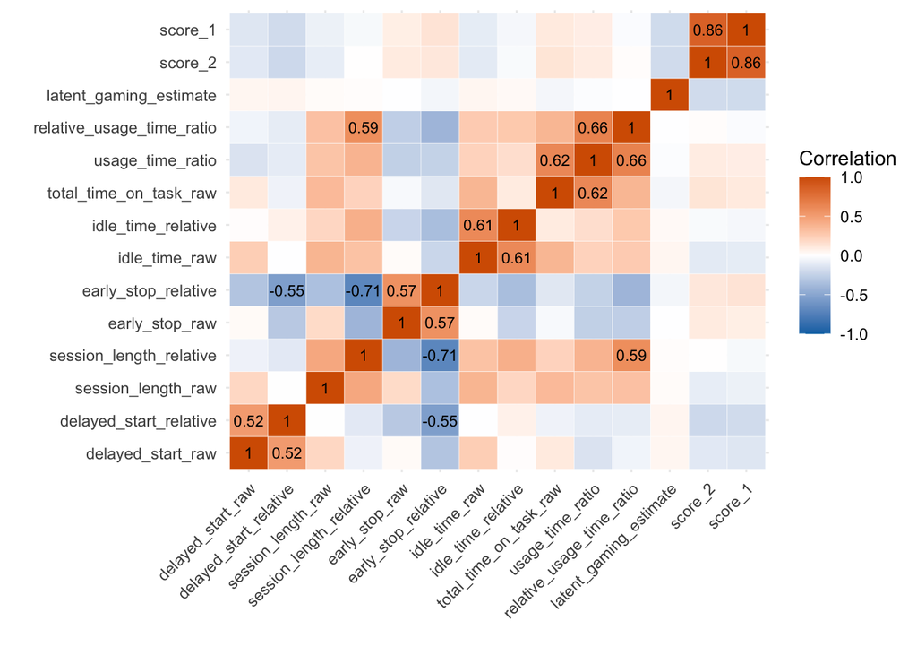

```r
# Calculate correlation
corr_matrix <- cor(df_predictive_validity_temp, use = "complete.obs")
melted_corr <- melt(corr_matrix)

ggplot(melted_corr, aes(Var1, Var2, fill = value)) +
  geom_tile(color = "white") +
  geom_text(aes(label = ifelse(abs(value) > 0.5, round(value, 2), "")),
            size = 3) +  # Only show if |correlation| > 0.5
  scale_fill_gradient2(low = "#0072B2", high = "#D55E00", mid = "white",
                       midpoint = 0, limit = c(-1, 1)) +
  theme_minimal() +
  theme(axis.text.x = element_text(angle = 45, hjust = 1)) +
  labs(x = "", y = "", fill = "Correlation")
```

```r
df_predictive_validity_temp_ <- df_predictive_validity_temp %>%
  select(-c(early_stop_relative, session_length_raw, delayed_start_raw, early_stop_raw))
```

```r
library(car)
full_model <- lm(score_2 ~ ., data = df_predictive_validity_temp_)
null_model <- lm(score_2 ~ 1, data = df_predictive_validity_temp_)  # Only intercept
backward_model <- step(full_model, direction = "backward", trace = FALSE, k = log(nrow(df_predictive_validity_temp_)))
summary(backward_model)
```

```
##
## Call:
## lm(formula = score_2 ~ delayed_start_relative + idle_time_raw +
##     idle_time_relative + total_time_on_task_raw + score_1, data = df_predictive_validity_temp_)
##
## Residuals:
##      Min       1Q   Median       3Q      Max
## -2.45007 -0.31727  0.00109  0.33417  1.84650
##
## Coefficients:
##                          Estimate Std. Error t value Pr(>|t|)
## (Intercept)             5.473e-15  1.387e-02   0.000 1.000000
## delayed_start_relative -5.094e-02  1.421e-02  -3.586 0.000348 ***
## idle_time_raw          -9.115e-02  1.935e-02  -4.711 2.72e-06 ***
## idle_time_relative      5.900e-02  1.792e-02   3.291 0.001023 **
## total_time_on_task_raw  6.618e-02  1.537e-02   4.306 1.78e-05 ***
## score_1                 8.329e-01  1.441e-02  57.818  < 2e-16 ***
## ---
## Signif. codes:  0 '***' 0.001 '**' 0.01 '*' 0.05 '.' 0.1 ' ' 1
##
## Residual standard error: 0.5092 on 1341 degrees of freedom
## Multiple R-squared:  0.7417, Adjusted R-squared:  0.7408
## F-statistic: 770.2 on 5 and 1341 DF,  p-value: < 2.2e-16
```

```r
forward_model <- step(null_model, scope = list(lower = null_model, upper = full_model),
                      direction = "forward", trace = FALSE, k = log(nrow(df_predictive_validity_temp_)))
summary(forward_model)
```

```
##
## Call:
## lm(formula = score_2 ~ score_1 + delayed_start_relative, data = df_predictive_validity_temp_)
##
## Residuals:
##      Min       1Q   Median       3Q      Max
## -2.44131 -0.31221  0.00261  0.33338  1.88520
##
## Coefficients:
##                          Estimate Std. Error t value Pr(>|t|)
## (Intercept)             1.259e-15  1.401e-02    0.00 1.000000
## score_1                 8.474e-01  1.428e-02   59.36  < 2e-16 ***
## delayed_start_relative -4.839e-02  1.428e-02   -3.39 0.000719 ***
## ---
## Signif. codes:  0 '***' 0.001 '**' 0.01 '*' 0.05 '.' 0.1 ' ' 1
##
## Residual standard error: 0.5142 on 1344 degrees of freedom
## Multiple R-squared:  0.736,  Adjusted R-squared:  0.7356
## F-statistic:  1874 on 2 and 1344 DF,  p-value: < 2.2e-16
```

```r
tab_model(backward_model, forward_model,
    lm(score_2~delayed_start_relative + score_1 + latent_gaming_estimate, data = df_predictive_validity_temp),
    lm(score_2~delayed_start_relative + early_stop_raw + idle_time_raw + score_1, data = df_predictive_validity_temp),
    wrap.labels = 80, p.style = 'stars', show.ci = FALSE)
```

score_2

score_2

score_2

score_2

Predictors

Estimates

Estimates

Estimates

Estimates

(Intercept)

0.00

0.00

0.00

0.00

delayed start relative

-0.05 ***

-0.05 ***

-0.05 ***

-0.04 **

idle time raw

-0.09 ***

-0.03 *

idle time relative

0.06 **

total time on task raw

0.07 ***

score 1

0.83 ***

0.85 ***

0.84 ***

0.84 ***

latent gaming estimate

-0.03

early stop raw

0.02

Observations

1347

1347

1347

1347

R<sup>2</sup> / R<sup>2</sup> adjusted

0.742 / 0.741

0.736 / 0.736

0.737 / 0.736

0.737 / 0.736

- p<0.05 ** p<0.01 *** p<0.001

```r
vif(backward_model)
```

```
## delayed_start_relative          idle_time_raw     idle_time_relative
##               1.047994               1.943778               1.668097
## total_time_on_task_raw                score_1
##               1.226350               1.077491
```

```r
vif(forward_model)
```

```
##                score_1 delayed_start_relative
##               1.037542               1.037542
```

```r
BIC(backward_model, forward_model, lm(score_2~delayed_start_relative + score_1 + latent_gaming_estimate, data = df_predictive_validity_temp),
    lm(score_2~delayed_start_relative + early_stop_raw + idle_time_raw + score_1, data = df_predictive_validity_temp))
```

|  | df | BIC |
| --- | --- | --- |
| backward_model | 7 | 2048.583 |
| forward_model | 4 | 2056.376 |
| lm(score_2 ~ delayed_start_relative + score_1 + latent_gaming_estimate, data = df_predictive_validity_temp) | 5 | 2060.473 |
| lm(score_2 ~ delayed_start_relative + early_stop_raw + idle_time_raw + score_1, data = df_predictive_validity_temp) | 6 | 2065.217 |

skewness check

```r
library(e1071)
skewness(df_predictive_validity_temp_$idle_time_raw)
```

```
## [1] 1.477314
```

```r
skewness(df_predictive_validity_temp$early_stop_raw)
```

```
## [1] 0.5826455
```

## JEDM: Paper Replication Model

```r
tab_model(lm(score_2~delayed_start_relative + score_1 + latent_gaming_estimate, data = df_predictive_validity_temp),
          lm(score_2~delayed_start_relative + early_stop_raw + idle_time_raw + score_1, data = df_predictive_validity_temp),
          wrap.labels = 80, p.style = 'stars', show.ci = FALSE, p.threshold = c(0.1, 0.05, 0.01, 0.001))
```

score_2

score_2

Predictors

Estimates

Estimates

(Intercept)

0.00

0.00

delayed start relative

-0.05 ***

-0.04 ***

score 1

0.84 ***

0.84 ***

latent gaming estimate

-0.03 *

early stop raw

0.02

idle time raw

-0.03 **

Observations

1347

1347

R<sup>2</sup> / R<sup>2</sup> adjusted

0.737 / 0.736

0.737 / 0.736

- p<0.1 ** p<0.05 *** p<0.01

```r
df_predictive_validity_temp__ <- df_predictive_validity_temp_ %>% select(-score_1)

library(car)
full_model <- lm(score_2 ~ ., data = df_predictive_validity_temp__)
null_model <- lm(score_2 ~ 1, data = df_predictive_validity_temp__)  # Only intercept
backward_model <- step(full_model, direction = "backward", trace = FALSE, k = log(nrow(df_predictive_validity_temp__)))
summary(backward_model)
```

```
##
## Call:
## lm(formula = score_2 ~ delayed_start_relative + idle_time_raw +
##     idle_time_relative + total_time_on_task_raw + latent_gaming_estimate,
##     data = df_predictive_validity_temp__)
##
## Residuals:
##     Min      1Q  Median      3Q     Max
## -3.3627 -0.6065  0.0748  0.6468  2.5277
##
## Coefficients:
##                          Estimate Std. Error t value Pr(>|t|)
## (Intercept)             1.267e-14  2.554e-02   0.000        1
## delayed_start_relative -1.982e-01  2.571e-02  -7.707 2.49e-14 ***
## idle_time_raw          -2.613e-01  3.519e-02  -7.426 1.98e-13 ***
## idle_time_relative      1.314e-01  3.291e-02   3.994 6.85e-05 ***
## total_time_on_task_raw  1.929e-01  2.800e-02   6.890 8.56e-12 ***
## latent_gaming_estimate -1.648e-01  2.565e-02  -6.425 1.82e-10 ***
## ---
## Signif. codes:  0 '***' 0.001 '**' 0.01 '*' 0.05 '.' 0.1 ' ' 1
##
## Residual standard error: 0.9372 on 1341 degrees of freedom
## Multiple R-squared:  0.1248, Adjusted R-squared:  0.1216
## F-statistic: 38.25 on 5 and 1341 DF,  p-value: < 2.2e-16
```

```r
forward_model <- step(null_model, scope = list(lower = null_model, upper = full_model),
                      direction = "forward", trace = FALSE, k = log(nrow(df_predictive_validity_temp__)))
summary(forward_model)
```

```
##
## Call:
## lm(formula = score_2 ~ delayed_start_relative + latent_gaming_estimate +
##     idle_time_raw + total_time_on_task_raw + idle_time_relative,
##     data = df_predictive_validity_temp__)
##
## Residuals:
##     Min      1Q  Median      3Q     Max
## -3.3627 -0.6065  0.0748  0.6468  2.5277
##
## Coefficients:
##                          Estimate Std. Error t value Pr(>|t|)
## (Intercept)             1.267e-14  2.554e-02   0.000        1
## delayed_start_relative -1.982e-01  2.571e-02  -7.707 2.49e-14 ***
## latent_gaming_estimate -1.648e-01  2.565e-02  -6.425 1.82e-10 ***
## idle_time_raw          -2.613e-01  3.519e-02  -7.426 1.98e-13 ***
## total_time_on_task_raw  1.929e-01  2.800e-02   6.890 8.56e-12 ***
## idle_time_relative      1.314e-01  3.291e-02   3.994 6.85e-05 ***
## ---
## Signif. codes:  0 '***' 0.001 '**' 0.01 '*' 0.05 '.' 0.1 ' ' 1
##
## Residual standard error: 0.9372 on 1341 degrees of freedom
## Multiple R-squared:  0.1248, Adjusted R-squared:  0.1216
## F-statistic: 38.25 on 5 and 1341 DF,  p-value: < 2.2e-16
```

```r
tab_model(backward_model, forward_model,
    wrap.labels = 80, p.style = 'stars', show.ci = FALSE)
```

score_2

score_2

Predictors

Estimates

Estimates

(Intercept)

0.00

0.00

delayed start relative

-0.20 ***

-0.20 ***

idle time raw

-0.26 ***

-0.26 ***

idle time relative

0.13 ***

0.13 ***

total time on task raw

0.19 ***

0.19 ***

latent gaming estimate

-0.16 ***

-0.16 ***

Observations

1347

1347

R<sup>2</sup> / R<sup>2</sup> adjusted

0.125 / 0.122

0.125 / 0.122

- p<0.05 ** p<0.01 *** p<0.001

```r
vif(backward_model)
```

```
## delayed_start_relative          idle_time_raw     idle_time_relative
##               1.012903               1.897724               1.659629
## total_time_on_task_raw latent_gaming_estimate
##               1.201630               1.008417
```

```r
vif(forward_model)
```

```
## delayed_start_relative latent_gaming_estimate          idle_time_raw
##               1.012903               1.008417               1.897724
## total_time_on_task_raw     idle_time_relative
##               1.201630               1.659629
```

```r
BIC(backward_model, forward_model)
```

|  | df | BIC |
| --- | --- | --- |
| backward_model | 7 | 3692.459 |
| forward_model | 7 | 3692.459 |

```r
library(glmnet)
df_predictive_validity_temp_robust <- df_predictive_validity_temp_

y <- df_predictive_validity_temp_robust$score_2   # change "y" to your outcome column name

x <- as.matrix(df_predictive_validity_temp_robust %>% dplyr::select(-score_2))
x <- scale(x, center = TRUE, scale = TRUE)

# Fit LASSO with cross-validation
set.seed(123)  # for reproducibility
cv_fit <- cv.glmnet(
  x,
  y,
  alpha = 1,
  family = "gaussian"
)

coef(cv_fit, s = "lambda.min")
```

```
## 10 x 1 sparse Matrix of class "dgCMatrix"
##                              lambda.min
## (Intercept)                2.336761e-16
## delayed_start_relative    -4.776000e-02
## session_length_relative    2.158246e-02
## idle_time_raw             -9.070960e-02
## idle_time_relative         5.007648e-02
## total_time_on_task_raw     8.113117e-02
## usage_time_ratio          -4.357096e-02
## relative_usage_time_ratio  1.740016e-02
## latent_gaming_estimate    -2.089031e-02
## score_1                    8.311415e-01
```

```r
coef(cv_fit, s = "lambda.1se")
```

```
## 10 x 1 sparse Matrix of class "dgCMatrix"
##                            lambda.1se
## (Intercept)               2.43951e-16
## delayed_start_relative    .
## session_length_relative   .
## idle_time_raw             .
## idle_time_relative        .
## total_time_on_task_raw    .
## usage_time_ratio          .
## relative_usage_time_ratio .
## latent_gaming_estimate    .
## score_1                   7.80346e-01
```

```r
coef_min <- coef(cv_fit, s = "lambda.min")
coef_min_mat <- as.matrix(coef_min)
nz_min <- rownames(coef_min_mat)[coef_min_mat[, 1] != 0]
nz_min <- setdiff(nz_min, "(Intercept)")
nz_min
```

```
## [1] "delayed_start_relative"    "session_length_relative"
## [3] "idle_time_raw"             "idle_time_relative"
## [5] "total_time_on_task_raw"    "usage_time_ratio"
## [7] "relative_usage_time_ratio" "latent_gaming_estimate"
## [9] "score_1"
```

```r
selected_vars <- nz_min
form <- as.formula(
  paste("score_2 ~", paste(selected_vars, collapse = " + "))
)
lm_fit <- lm(form, data = df_predictive_validity_temp_robust)
summary(lm_fit)
```

```
##
## Call:
## lm(formula = form, data = df_predictive_validity_temp_robust)
##
## Residuals:
##      Min       1Q   Median       3Q      Max
## -2.36421 -0.32416  0.00959  0.32726  1.85677
##
## Coefficients:
##                             Estimate Std. Error t value Pr(>|t|)
## (Intercept)                5.943e-15  1.385e-02   0.000 1.000000
## delayed_start_relative    -4.904e-02  1.438e-02  -3.410 0.000669 ***
## session_length_relative    2.182e-02  1.825e-02   1.195 0.232106
## idle_time_raw             -9.583e-02  1.949e-02  -4.917 9.86e-07 ***
## idle_time_relative         5.398e-02  1.906e-02   2.832 0.004697 **
## total_time_on_task_raw     8.659e-02  1.943e-02   4.457 9.00e-06 ***
## usage_time_ratio          -5.040e-02  2.226e-02  -2.265 0.023683 *
## relative_usage_time_ratio  2.107e-02  2.126e-02   0.991 0.321871
## latent_gaming_estimate    -2.163e-02  1.414e-02  -1.530 0.126358
## score_1                    8.316e-01  1.468e-02  56.652  < 2e-16 ***
## ---
## Signif. codes:  0 '***' 0.001 '**' 0.01 '*' 0.05 '.' 0.1 ' ' 1
##
## Residual standard error: 0.5081 on 1337 degrees of freedom
## Multiple R-squared:  0.7435, Adjusted R-squared:  0.7418
## F-statistic: 430.7 on 9 and 1337 DF,  p-value: < 2.2e-16
```

```r
tab_model(lm_fit)
```

|  | score_2 |  |  |
| --- | --- | --- | --- |
| Predictors | Estimates | CI | p |
| (Intercept) | 0.00 | -0.03 – 0.03 | 1.000 |
| delayed start relative | -0.05 | -0.08 – -0.02 | **0.001** |
| session length relative | 0.02 | -0.01 – 0.06 | 0.232 |
| idle time raw | -0.10 | -0.13 – -0.06 | **<0.001** |
| idle time relative | 0.05 | 0.02 – 0.09 | **0.005** |
| total time on task raw | 0.09 | 0.05 – 0.12 | **<0.001** |
| usage time ratio | -0.05 | -0.09 – -0.01 | **0.024** |
| relative usage time ratio | 0.02 | -0.02 – 0.06 | 0.322 |
| latent gaming estimate | -0.02 | -0.05 – 0.01 | 0.126 |
| score 1 | 0.83 | 0.80 – 0.86 | **<0.001** |
| Observations | 1347 |  |  |
| R<sup>2</sup> / R<sup>2</sup> adjusted | 0.744 / 0.742 |  |  |